# Report on combining (Stack) C+T predictor

DANG Vu-Lam

## Methods

In this RMD documents there are 5 methods demonstrated:

- SCT
- XGBoost (with SCT 1(st) layer)
- Lassosum
- Random Forest (with SCT 1(st) layer)
- Neural Net (with SCT 1(st) layer)

More promising (SCT, XGBoost, Lassosum, Random Forest) are place first, and Neural Net are included for reference.

For some reason I can not get Keras to work with SCT first layer (always return AUC of 0.5). This can either be a problem of the target function (I have yet to find a good function that operate well), or a bug within Keras (unlikely). Or perhap the Euclid distance after C+T layer are too small for neuralnet - that’s why regression based method work better?

## Required packages:

- bigstatsr
- bigsnpr
- lassosum
- data.table
- xgboost
- ranger
- keras

```r
library(bigstatsr)
library(bigsnpr)
library(lassosum)
library(data.table)
library(xgboost)
library(ranger)
library(keras)
```

## Dataset

*Please change working direction in `directory`*

I use the “Simus” simulated dataset provided by Florian. This dataset contain ~650,000 SNPs in 2 chromosomes. 20% of them are cases and the rest 80% are controls.

```r
setwd(directory)
# Train data
sumstats <- bigreadr::fread2(file_sumstat)
# snp_readBed(paste(file_train, "bed", sep='.'))
train <- snp_attach(paste(file_train, "rds", sep='.'))
G.train <- train$genotypes
CHR <- train$map$chromosome
POS <- train$map$physical.pos
NCORES <- nb_cores()
lpval <- -log10(sumstats$pval)
y.train <- train$fam$affection

# Test data
# snp_readBed(paste(file_test, "bed", sep='.'))
test <- snp_attach(paste(file_test, "rds", sep='.'))
G.test <- test$genotypes
#
```

## C+T step

Generating a matrix of C+T with varied clumping radius and $p-value$ thresholds.

$\beta s$ and $p-values$ are aquired in sumstats file (see `sumstats.txt`)

```r
all_keep <- snp_grid_clumping(G.train, CHR, POS, lpval, ncores = NCORES)
PRS <-snp_grid_PRS(G.train,all_keep = all_keep, betas = sumstats$beta,lpval)
PRS_test <- snp_grid_PRS(G.test, all_keep = all_keep, betas = sumstats$beta,lpval)
```

Other than SCT, other methods require DataFrame or R Matrix than FBM to manage data. I converted the FBM output of C+T to DataFrame and change the corresponding columns.

## Data treatment: Oversampling

```r
y_case <- which(train$fam$affection %in% c(1))
for (i in range(1, 10)){
  y.train <- append(y.train, train$fam$affection[y_case])
  ds <- rbind(ds, PRS[y_case,])
}
ds.FBM <- as_FBM(ds)
```

## Method 1: SCT

No parameters required. Combining (Sparse Logistic Regression) C+T predictors for best result.

```r
AUC(pred = pred.SCT, test$fam$affection)
```

```
## [1] 0.7824107
```

## Method 2: XGBoost

For experimentation, I run 9 different *max_depth* and 9 *nrounds*. Each combination is repeated 10 times and the mean value calculated to rule out the randomess of *gblinear* booster

```r
AUCs
```

```
##            [,1]      [,2]      [,3]      [,4]      [,5]      [,6]
##  [1,] 0.7809365 0.7813137 0.7817648 0.7820310 0.7819990 0.7818963
##  [2,] 0.7808746 0.7815682 0.7816594 0.7820550 0.7820346 0.7818610
##  [3,] 0.7807512 0.7818230 0.7818196 0.7820333 0.7819446 0.7820420
##  [4,] 0.7810039 0.7816137 0.7818937 0.7818578 0.7819579 0.7818238
##  [5,] 0.7809052 0.7814805 0.7816621 0.7819018 0.7818826 0.7818065
##  [6,] 0.7810175 0.7815691 0.7817364 0.7817640 0.7819517 0.7818490
##  [7,] 0.7811061 0.7816980 0.7817624 0.7818428 0.7821071 0.7818385
##  [8,] 0.7810890 0.7818747 0.7818224 0.7819294 0.7819152 0.7818184
##  [9,] 0.7811708 0.7815460 0.7818365 0.7819380 0.7819986 0.7819875
## [10,]        NA        NA        NA        NA        NA        NA
##            [,7]      [,8]      [,9] [,10]
##  [1,] 0.7817706 0.7814940 0.7813819    NA
##  [2,] 0.7816839 0.7815991 0.7815044    NA
##  [3,] 0.7817853 0.7817110 0.7814769    NA
##  [4,] 0.7817440 0.7816575 0.7813900    NA
##  [5,] 0.7817042 0.7815616 0.7813549    NA
##  [6,] 0.7817291 0.7815552 0.7813632    NA
##  [7,] 0.7816843 0.7816044 0.7813753    NA
##  [8,] 0.7817450 0.7817192 0.7814930    NA
##  [9,] 0.7817717 0.7817646 0.7815330    NA
## [10,]        NA        NA        NA    NA
```

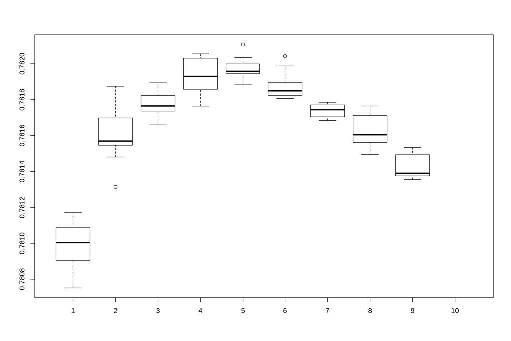

```r
boxplot(AUCs)
```

## Method 3: Lassosum

Lassosum use L1 regularization to better fit the regression model.

For basic L1 regularization of Linear Regression, 2 metaparameters are required: a learning rate $\alpha$ and a regularization parameter $\lambda$. However, *lassosum* does not require these parameters, as the software automatically scan the parameters space and select the best $\alpha$ and $\lambda$

```r
AUC(v$best.pgs, v$pheno)
```

```
## [1] 0.7308175
```

## Method 4: Random Forest

The code in this session will sweep through the parameters: 1 to 10 trees and alpha from 0.1 to 1 (0.1 increment).

```r
AUCs
```

```
##            [,1]      [,2]      [,3]      [,4]      [,5]      [,6]
##  [1,] 0.7497366 0.7466340 0.7552112 0.7535140 0.7533033 0.7531235
##  [2,] 0.7524137 0.7501430 0.7531712 0.7525826 0.7547430 0.7547622
##  [3,] 0.7526929 0.7538241 0.7522883 0.7538400 0.7549587 0.7538927
##  [4,] 0.7477234 0.7494683 0.7525065 0.7525308 0.7553282 0.7521855
##  [5,] 0.7428124 0.7508812 0.7513444 0.7536427 0.7527381 0.7531478
##  [6,] 0.7567779 0.7495092 0.7543132 0.7532414 0.7540014 0.7568565
##  [7,] 0.7531837 0.7548759 0.7539805 0.7537798 0.7526511 0.7569660
##  [8,] 0.7515860 0.7526754 0.7551827 0.7545824 0.7538007 0.7536042
##  [9,] 0.7465278 0.7490218 0.7509155 0.7541025 0.7540783 0.7530315
## [10,] 0.7521704 0.7512415 0.7542104 0.7506546 0.7513678 0.7516136
##            [,7]      [,8]      [,9]     [,10]
##  [1,] 0.7531703 0.7548107 0.7552454 0.7550088
##  [2,] 0.7526486 0.7538534 0.7531361 0.7554620
##  [3,] 0.7533827 0.7541811 0.7521896 0.7531478
##  [4,] 0.7541853 0.7549670 0.7556100 0.7545791
##  [5,] 0.7541594 0.7553073 0.7522164 0.7556651
##  [6,] 0.7540164 0.7519196 0.7517800 0.7542748
##  [7,] 0.7541786 0.7519263 0.7551869 0.7548742
##  [8,] 0.7526470 0.7543718 0.7524772 0.7542279
##  [9,] 0.7537614 0.7534086 0.7537472 0.7546920
## [10,] 0.7523251 0.7532297 0.7544010 0.7539479
```

[figure not shown]

```r
plot(unlist(AUCs))
```

## Method 5: Nerual net (Keras)

For some reason, *keras* cannot return good result; the prediction always biased to controls. Even with adjusted weights and oversampling, the bias is still there and AUC is always $0.5$. I included it here in case I figure it out in the future.

In this example, I put a 10:1 weight ratio between case and control.

```r
y.train <- train$fam$affection

model <- keras_model_sequential()
model %>%
 layer_dense(units = 1000, activation = "softmax", input_shape = c(ncol(ds)), kernel_regularizer=regularizer_l1(0.02)) %>%
 # layer_dense(units = 1000, activation = "softmax", input_shape = c(2800)) %>%
 # layer_dropout(rate=0.1) %>%
 layer_dense(units = 2, activation = "softmax", kernel_regularizer=regularizer_l1(0.01))

model %>% compile(
 #loss = 'categorical_crossentropy',
 loss = 'mean_absolute_percentage_error',
 optimizer = 'SGD',
 metrics = c('accuracy')
)
PRS$show()
```

```
## A Filebacked Big Matrix of type 'float' with 8000 rows and 2800 columns.
```

```r
y.train <-  to_categorical(y.train)

history <- model$fit(
 ds, y.train,
 class_weight = list(1, 10),
 epochs = as.integer(10),
 batch_size = as.integer(28)
)
AUC(predict_classes(model, PRS_test[]), test$fam$affection)
```

```
## [1] 0.5
```